# Amy Shaw Dissertation Code Script

## Script setup

Load packages used in analysis

```r
library(dplyr)
library(tidyverse)
library(ggplot2)
library(patchwork)
library(data.table)
library(scales)
```

Define plotting theme for figures

```r
theme_fancy <- function() {
  theme_bw() +
    theme(
      text = element_text(family = "Helvetica"),
      axis.text = element_text(size = 8, color = "black"),
      axis.title = element_text(size = 10, color = "black"),
      axis.line.x = element_line(size = 0.3, color = "black"),
      axis.line.y = element_line(size = 0.3, color = "black"),
      axis.ticks = element_line(size = 0.3, color = "black"),
      panel.border = element_blank(),
      panel.grid.major.x = element_blank(),
      panel.grid.minor.x = element_blank(),
      panel.grid.minor.y = element_blank(),
      panel.grid.major.y = element_blank(),
      plot.margin = unit(c(0.5, 0.5, 0.5, 0.5), units = , "cm"),
      plot.title = element_text(
        size = 10,
        vjust = 1,
        hjust = 0.5,
        color = "black"
      ),
      legend.text = element_text(size = 9, color = "black"),
      legend.title = element_text(size = 9, color = "black"),
      legend.position = c(0.9, 0.9),
      legend.key.size = unit(0.7, "line"),
      legend.background = element_rect(
        color = "black",
        fill = "transparent",
        size = 2,
        linetype = "blank"
      )
    )
}
```

## Lamu Data importing and processing

In this section 11 csv files from the Global Mangrove Watch 3.0 dataset are imported and processed. Clips were made in QGIS for Lamu County for the available observation years of 1996, 2007-2010 and 2015-2020.

The following processing steps are then taken for each imported data frame.

1. Rename the column labelled with the observation year to *Mangroves*. This column contains mangrove coverage in square metres for the QGIS pixel in question.
2. Create a column called *year* and set the value to the observation year.
3. Drop columns that are not required retaining the *Mangroves* and *year* columns.

### Lamu County mangrove cover data import and initial processing

Import Lamu County 1996 mangrove data.

```r
Lamu1996Data <- read_csv("Data/Lamu1996Data.csv")
Lamu1996Data
```

| PXLVAL | clipped1996data | 1996 |
| --- | --- | --- |
| 1 | 6682.441 | 6682 |
| 1 | 15794.859 | 15795 |
| 1 | 607.495 | 607 |
| 1 | 607.494 | 607 |
| 1 | 607.494 | 607 |
| 1 | 5467.441 | 5467 |
| 1 | 1214.987 | 1215 |
| 1 | 607.493 | 607 |
| 1 | 607.493 | 607 |
| 1 | 607.493 | 607 |

[output cut: 990 more lines]

Rename *1996* column to *Mangroves*.

```r
names(Lamu1996Data)[names(Lamu1996Data) == '1996'] <- 'Mangroves'
Lamu1996Data
```

| PXLVAL | clipped1996data | Mangroves |
| --- | --- | --- |
| 1 | 6682.441 | 6682 |
| 1 | 15794.859 | 15795 |
| 1 | 607.495 | 607 |
| 1 | 607.494 | 607 |
| 1 | 607.494 | 607 |
| 1 | 5467.441 | 5467 |
| 1 | 1214.987 | 1215 |
| 1 | 607.493 | 607 |
| 1 | 607.493 | 607 |
| 1 | 607.493 | 607 |

[output cut: 990 more lines]

Create *year* column and set the value to ‘1996’.

```r
Lamu1996Data <- cbind(Lamu1996Data, year="1996")
Lamu1996Data
```

| PXLVAL | clipped1996data | Mangroves | year |
| --- | --- | --- | --- |
| 1 | 6682.441 | 6682 | 1996 |
| 1 | 15794.859 | 15795 | 1996 |
| 1 | 607.495 | 607 | 1996 |
| 1 | 607.494 | 607 | 1996 |
| 1 | 607.494 | 607 | 1996 |
| 1 | 5467.441 | 5467 | 1996 |
| 1 | 1214.987 | 1215 | 1996 |
| 1 | 607.493 | 607 | 1996 |
| 1 | 607.493 | 607 | 1996 |
| 1 | 607.493 | 607 | 1996 |

[output cut: 990 more lines]

Drop columns *PXLVAL* and *clipped1996data* as neither is needed.

```r
Lamu1996Data = subset(Lamu1996Data,select = -c(PXLVAL, clipped1996data))
Lamu1996Data
```

|  | Mangroves | year |
| --- | --- | --- |
| 1 | 6682 | 1996 |
| 2 | 15795 | 1996 |
| 3 | 607 | 1996 |
| 4 | 607 | 1996 |
| 5 | 607 | 1996 |
| 6 | 5467 | 1996 |
| 7 | 1215 | 1996 |
| 8 | 607 | 1996 |
| 9 | 607 | 1996 |
| 10 | 607 | 1996 |

[output cut: 990 more lines]

Import Lamu County 2007 mangrove data.

```r
Lamu2007Data <- read_csv("Data/Lamu2007Data.csv")
Lamu2007Data
```

| PXLVAL | clipped2007data | 2007 |
| --- | --- | --- |
| 1 | 607.495 | 607 |
| 1 | 15187.368 | 15187 |
| 1 | 607.495 | 607 |
| 1 | 41917.125 | 41917 |
| 1 | 44954.595 | 44955 |
| 1 | 607.495 | 607 |
| 1 | 44954.594 | 44955 |
| 1 | 592305.554 | 592306 |
| 1 | 2429.975 | 2430 |
| 1 | 65609.371 | 65609 |

[output cut: 990 more lines]

Rename *2007* column to *Mangroves*.

```r
names(Lamu2007Data)[names(Lamu2007Data) == '2007'] <- 'Mangroves'
Lamu2007Data
```

| PXLVAL | clipped2007data | Mangroves |
| --- | --- | --- |
| 1 | 607.495 | 607 |
| 1 | 15187.368 | 15187 |
| 1 | 607.495 | 607 |
| 1 | 41917.125 | 41917 |
| 1 | 44954.595 | 44955 |
| 1 | 607.495 | 607 |
| 1 | 44954.594 | 44955 |
| 1 | 592305.554 | 592306 |
| 1 | 2429.975 | 2430 |
| 1 | 65609.371 | 65609 |

[output cut: 990 more lines]

Create *year* column and set the value to ‘2007’.

```r
Lamu2007Data <- cbind(Lamu2007Data, year="2007")
Lamu2007Data
```

| PXLVAL | clipped2007data | Mangroves | year |
| --- | --- | --- | --- |
| 1 | 607.495 | 607 | 2007 |
| 1 | 15187.368 | 15187 | 2007 |
| 1 | 607.495 | 607 | 2007 |
| 1 | 41917.125 | 41917 | 2007 |
| 1 | 44954.595 | 44955 | 2007 |
| 1 | 607.495 | 607 | 2007 |
| 1 | 44954.594 | 44955 | 2007 |
| 1 | 592305.554 | 592306 | 2007 |
| 1 | 2429.975 | 2430 | 2007 |
| 1 | 65609.371 | 65609 | 2007 |

[output cut: 990 more lines]

Drop columns *PXLVAL* and *clipped2007data* as neither is needed.

```r
Lamu2007Data = subset(Lamu2007Data,select = -c(PXLVAL, clipped2007data))
Lamu2007Data
```

|  | Mangroves | year |
| --- | --- | --- |
| 1 | 607 | 2007 |
| 2 | 15187 | 2007 |
| 3 | 607 | 2007 |
| 4 | 41917 | 2007 |
| 5 | 44955 | 2007 |
| 6 | 607 | 2007 |
| 7 | 44955 | 2007 |
| 8 | 592306 | 2007 |
| 9 | 2430 | 2007 |
| 10 | 65609 | 2007 |

[output cut: 990 more lines]

Import Lamu County 2008 mangrove data.

```r
Lamu2008Data <- read_csv("Data/Lamu2008Data.csv")
Lamu2008Data
```

| PXLVAL | clipped2008data | 2008 |
| --- | --- | --- |
| 1 | 607.495 | 607 |
| 1 | 12149.892 | 12150 |
| 1 | 607.495 | 607 |
| 1 | 1822.485 | 1822 |
| 1 | 41309.630 | 41310 |
| 1 | 42524.621 | 42525 |
| 1 | 607.495 | 607 |
| 1 | 38879.647 | 38880 |
| 1 | 2429.977 | 2430 |
| 1 | 607.494 | 607 |

[output cut: 990 more lines]

Rename *2008* column to *Mangroves*.

```r
names(Lamu2008Data)[names(Lamu2008Data) == '2008'] <- 'Mangroves'
Lamu2008Data
```

| PXLVAL | clipped2008data | Mangroves |
| --- | --- | --- |
| 1 | 607.495 | 607 |
| 1 | 12149.892 | 12150 |
| 1 | 607.495 | 607 |
| 1 | 1822.485 | 1822 |
| 1 | 41309.630 | 41310 |
| 1 | 42524.621 | 42525 |
| 1 | 607.495 | 607 |
| 1 | 38879.647 | 38880 |
| 1 | 2429.977 | 2430 |
| 1 | 607.494 | 607 |

[output cut: 990 more lines]

Create *year* column and set the value to ‘2008’.

```r
Lamu2008Data <- cbind(Lamu2008Data, year="2008")
Lamu2008Data
```

| PXLVAL | clipped2008data | Mangroves | year |
| --- | --- | --- | --- |
| 1 | 607.495 | 607 | 2008 |
| 1 | 12149.892 | 12150 | 2008 |
| 1 | 607.495 | 607 | 2008 |
| 1 | 1822.485 | 1822 | 2008 |
| 1 | 41309.630 | 41310 | 2008 |
| 1 | 42524.621 | 42525 | 2008 |
| 1 | 607.495 | 607 | 2008 |
| 1 | 38879.647 | 38880 | 2008 |
| 1 | 2429.977 | 2430 | 2008 |
| 1 | 607.494 | 607 | 2008 |

[output cut: 990 more lines]

Drop columns *PXLVAL* and *clipped2008data* as neither is needed.

```r
Lamu2008Data = subset(Lamu2008Data,select = -c(PXLVAL, clipped2008data))
Lamu2008Data
```

|  | Mangroves | year |
| --- | --- | --- |
| 1 | 607 | 2008 |
| 2 | 12150 | 2008 |
| 3 | 607 | 2008 |
| 4 | 1822 | 2008 |
| 5 | 41310 | 2008 |
| 6 | 42525 | 2008 |
| 7 | 607 | 2008 |
| 8 | 38880 | 2008 |
| 9 | 2430 | 2008 |
| 10 | 607 | 2008 |

[output cut: 990 more lines]

Import Lamu County 2009 mangrove data.

```r
Lamu2009Data <- read_csv("Data/Lamu2009Data.csv")
Lamu2009Data
```

| PXLVAL | clipped2009data | 2009 |
| --- | --- | --- |
| 1 | 607.495 | 607 |
| 1 | 607.495 | 607 |
| 1 | 1822.485 | 1822 |
| 1 | 41309.631 | 41310 |
| 1 | 40094.643 | 40095 |
| 1 | 607.495 | 607 |
| 1 | 40702.134 | 40702 |
| 1 | 1214.989 | 1215 |
| 1 | 592913.049 | 592913 |
| 1 | 607.494 | 607 |

[output cut: 885 more lines]

Rename *2009* column to *Mangroves*.

```r
names(Lamu2009Data)[names(Lamu2009Data) == '2009'] <- 'Mangroves'
Lamu2009Data
```

| PXLVAL | clipped2009data | Mangroves |
| --- | --- | --- |
| 1 | 607.495 | 607 |
| 1 | 607.495 | 607 |
| 1 | 1822.485 | 1822 |
| 1 | 41309.631 | 41310 |
| 1 | 40094.643 | 40095 |
| 1 | 607.495 | 607 |
| 1 | 40702.134 | 40702 |
| 1 | 1214.989 | 1215 |
| 1 | 592913.049 | 592913 |
| 1 | 607.494 | 607 |

[output cut: 885 more lines]

Create *year* column and set the value to ‘2009’.

```r
Lamu2009Data <- cbind(Lamu2009Data, year="2009")
Lamu2009Data
```

| PXLVAL | clipped2009data | Mangroves | year |
| --- | --- | --- | --- |
| 1 | 607.495 | 607 | 2009 |
| 1 | 607.495 | 607 | 2009 |
| 1 | 1822.485 | 1822 | 2009 |
| 1 | 41309.631 | 41310 | 2009 |
| 1 | 40094.643 | 40095 | 2009 |
| 1 | 607.495 | 607 | 2009 |
| 1 | 40702.134 | 40702 | 2009 |
| 1 | 1214.989 | 1215 | 2009 |
| 1 | 592913.049 | 592913 | 2009 |
| 1 | 607.494 | 607 | 2009 |

[output cut: 885 more lines]

Drop columns *PXLVAL* and *clipped2009data* as neither is needed.

```r
Lamu2009Data = subset(Lamu2009Data,select = -c(PXLVAL, clipped2009data))
Lamu2009Data
```

|  | Mangroves | year |
| --- | --- | --- |
| 1 | 607 | 2009 |
| 2 | 607 | 2009 |
| 3 | 1822 | 2009 |
| 4 | 41310 | 2009 |
| 5 | 40095 | 2009 |
| 6 | 607 | 2009 |
| 7 | 40702 | 2009 |
| 8 | 1215 | 2009 |
| 9 | 592913 | 2009 |
| 10 | 607 | 2009 |

[output cut: 885 more lines]

Import Lamu County 2010 mangrove data.

```r
Lamu2010Data <- read_csv("Data/Lamu2010Data.csv")
Lamu2010Data
```

| PXLVAL | clipped2010data | 2010 |
| --- | --- | --- |
| 1 | 4252.680 | 4253 |
| 1 | 1215.051 | 1215 |
| 1 | 607.520 | 608 |
| 1 | 1037043.198 | 1037043 |
| 1 | 10935.352 | 10935 |
| 1 | 607.519 | 608 |
| 1 | 222959.921 | 222960 |
| 1 | 607.519 | 608 |
| 1 | 7290.223 | 7290 |
| 1 | 607.518 | 608 |

[output cut: 864 more lines]

Rename *2010* column to *Mangroves*.

```r
names(Lamu2010Data)[names(Lamu2010Data) == '2010'] <- 'Mangroves'
Lamu2010Data
```

| PXLVAL | clipped2010data | Mangroves |
| --- | --- | --- |
| 1 | 4252.680 | 4253 |
| 1 | 1215.051 | 1215 |
| 1 | 607.520 | 608 |
| 1 | 1037043.198 | 1037043 |
| 1 | 10935.352 | 10935 |
| 1 | 607.519 | 608 |
| 1 | 222959.921 | 222960 |
| 1 | 607.519 | 608 |
| 1 | 7290.223 | 7290 |
| 1 | 607.518 | 608 |

[output cut: 864 more lines]

Create *year* column and set the value to ‘2010’.

```r
Lamu2010Data <- cbind(Lamu2010Data, year="2010")
Lamu2010Data
```

| PXLVAL | clipped2010data | Mangroves | year |
| --- | --- | --- | --- |
| 1 | 4252.680 | 4253 | 2010 |
| 1 | 1215.051 | 1215 | 2010 |
| 1 | 607.520 | 608 | 2010 |
| 1 | 1037043.198 | 1037043 | 2010 |
| 1 | 10935.352 | 10935 | 2010 |
| 1 | 607.519 | 608 | 2010 |
| 1 | 222959.921 | 222960 | 2010 |
| 1 | 607.519 | 608 | 2010 |
| 1 | 7290.223 | 7290 | 2010 |
| 1 | 607.518 | 608 | 2010 |

[output cut: 864 more lines]

Drop columns *PXLVAL* and *clipped2010data* as neither is needed.

```r
Lamu2010Data = subset(Lamu2010Data,select = -c(PXLVAL, clipped2010data))
Lamu2010Data
```

|  | Mangroves | year |
| --- | --- | --- |
| 1 | 4253 | 2010 |
| 2 | 1215 | 2010 |
| 3 | 608 | 2010 |
| 4 | 1037043 | 2010 |
| 5 | 10935 | 2010 |
| 6 | 608 | 2010 |
| 7 | 222960 | 2010 |
| 8 | 608 | 2010 |
| 9 | 7290 | 2010 |
| 10 | 608 | 2010 |

[output cut: 864 more lines]

Import Lamu County 2015 mangrove data.

```r
Lamu2015Data <- read_csv("Data/Lamu2015Data.csv")
Lamu2015Data
```

| PXLVAL | clipped2015data | 2015 |
| --- | --- | --- |
| 1 | 4252.680 | 4253 |
| 1 | 1215.051 | 1215 |
| 1 | 1064381.722 | 1064382 |
| 1 | 10935.352 | 10935 |
| 1 | 607.519 | 608 |
| 1 | 224174.960 | 224175 |
| 1 | 9112.778 | 9113 |
| 1 | 34021.038 | 34021 |
| 1 | 607.518 | 608 |
| 1 | 1215.033 | 1215 |

[output cut: 899 more lines]

Rename *2015* column to *Mangroves*.

```r
names(Lamu2015Data)[names(Lamu2015Data) == '2015'] <- 'Mangroves'
Lamu2015Data
```

| PXLVAL | clipped2015data | Mangroves |
| --- | --- | --- |
| 1 | 4252.680 | 4253 |
| 1 | 1215.051 | 1215 |
| 1 | 1064381.722 | 1064382 |
| 1 | 10935.352 | 10935 |
| 1 | 607.519 | 608 |
| 1 | 224174.960 | 224175 |
| 1 | 9112.778 | 9113 |
| 1 | 34021.038 | 34021 |
| 1 | 607.518 | 608 |
| 1 | 1215.033 | 1215 |

[output cut: 899 more lines]

Create *year* column and set the value to ‘2015’.

```r
Lamu2015Data <- cbind(Lamu2015Data, year="2015")
Lamu2015Data
```

| PXLVAL | clipped2015data | Mangroves | year |
| --- | --- | --- | --- |
| 1 | 4252.680 | 4253 | 2015 |
| 1 | 1215.051 | 1215 | 2015 |
| 1 | 1064381.722 | 1064382 | 2015 |
| 1 | 10935.352 | 10935 | 2015 |
| 1 | 607.519 | 608 | 2015 |
| 1 | 224174.960 | 224175 | 2015 |
| 1 | 9112.778 | 9113 | 2015 |
| 1 | 34021.038 | 34021 | 2015 |
| 1 | 607.518 | 608 | 2015 |
| 1 | 1215.033 | 1215 | 2015 |

[output cut: 899 more lines]

Drop columns *PXLVAL* and *clipped2015data* as neither is needed.

```r
Lamu2015Data = subset(Lamu2015Data,select = -c(PXLVAL, clipped2015data))
Lamu2015Data
```

|  | Mangroves | year |
| --- | --- | --- |
| 1 | 4253 | 2015 |
| 2 | 1215 | 2015 |
| 3 | 1064382 | 2015 |
| 4 | 10935 | 2015 |
| 5 | 608 | 2015 |
| 6 | 224175 | 2015 |
| 7 | 9113 | 2015 |
| 8 | 34021 | 2015 |
| 9 | 608 | 2015 |
| 10 | 1215 | 2015 |

[output cut: 899 more lines]

Import Lamu County 2016 Mangrove data.

```r
Lamu2016Data <- read_csv("Data/Lamu2016Data.csv")
Lamu2016Data
```

| PXLVAL | clipped2016data | 2016 |
| --- | --- | --- |
| 1 | 17617.344 | 17617 |
| 1 | 2429.979 | 2430 |
| 1 | 607.495 | 607 |
| 1 | 607.494 | 607 |
| 1 | 607.494 | 607 |
| 1 | 607.494 | 607 |
| 1 | 3037.467 | 3037 |
| 1 | 1214.987 | 1215 |
| 1 | 393655.950 | 393656 |
| 1 | 607.492 | 607 |

[output cut: 962 more lines]

Rename *2016* column to *Mangroves*.

```r
names(Lamu2016Data)[names(Lamu2016Data) == '2016'] <- 'Mangroves'
Lamu2016Data
```

| PXLVAL | clipped2016data | Mangroves |
| --- | --- | --- |
| 1 | 17617.344 | 17617 |
| 1 | 2429.979 | 2430 |
| 1 | 607.495 | 607 |
| 1 | 607.494 | 607 |
| 1 | 607.494 | 607 |
| 1 | 607.494 | 607 |
| 1 | 3037.467 | 3037 |
| 1 | 1214.987 | 1215 |
| 1 | 393655.950 | 393656 |
| 1 | 607.492 | 607 |

[output cut: 962 more lines]

Create *year* column and set the value to ‘2016’.

```r
Lamu2016Data <- cbind(Lamu2016Data, year="2016")
Lamu2016Data
```

| PXLVAL | clipped2016data | Mangroves | year |
| --- | --- | --- | --- |
| 1 | 17617.344 | 17617 | 2016 |
| 1 | 2429.979 | 2430 | 2016 |
| 1 | 607.495 | 607 | 2016 |
| 1 | 607.494 | 607 | 2016 |
| 1 | 607.494 | 607 | 2016 |
| 1 | 607.494 | 607 | 2016 |
| 1 | 3037.467 | 3037 | 2016 |
| 1 | 1214.987 | 1215 | 2016 |
| 1 | 393655.950 | 393656 | 2016 |
| 1 | 607.492 | 607 | 2016 |

[output cut: 962 more lines]

Drop columns *PXLVAL* and *clipped2016data* as neither is needed.

```r
Lamu2016Data = subset(Lamu2016Data,select = -c(PXLVAL, clipped2016data))
Lamu2016Data
```

|  | Mangroves | year |
| --- | --- | --- |
| 1 | 17617 | 2016 |
| 2 | 2430 | 2016 |
| 3 | 607 | 2016 |
| 4 | 607 | 2016 |
| 5 | 607 | 2016 |
| 6 | 607 | 2016 |
| 7 | 3037 | 2016 |
| 8 | 1215 | 2016 |
| 9 | 393656 | 2016 |
| 10 | 607 | 2016 |

[output cut: 962 more lines]

Import Lamu County 2017 mangrove data.

```r
Lamu2017Data <- read_csv("Data/Lamu2017Data.csv")
Lamu2017Data
```

| PXLVAL | clipped2017data | 2017 |
| --- | --- | --- |
| 1 | 4860.206 | 4860 |
| 1 | 1215.051 | 1215 |
| 1 | 936194.755 | 936195 |
| 1 | 607.521 | 608 |
| 1 | 85660.416 | 85660 |
| 1 | 2430.079 | 2430 |
| 1 | 218099.757 | 218100 |
| 1 | 4860.156 | 4860 |
| 1 | 607.519 | 608 |
| 1 | 607.519 | 608 |

[output cut: 915 more lines]

Rename *2017* column to *Mangroves*.

```r
names(Lamu2017Data)[names(Lamu2017Data) == '2017'] <- 'Mangroves'
Lamu2017Data
```

| PXLVAL | clipped2017data | Mangroves |
| --- | --- | --- |
| 1 | 4860.206 | 4860 |
| 1 | 1215.051 | 1215 |
| 1 | 936194.755 | 936195 |
| 1 | 607.521 | 608 |
| 1 | 85660.416 | 85660 |
| 1 | 2430.079 | 2430 |
| 1 | 218099.757 | 218100 |
| 1 | 4860.156 | 4860 |
| 1 | 607.519 | 608 |
| 1 | 607.519 | 608 |

[output cut: 915 more lines]

Create *year* column and set the value to ‘2017’.

```r
Lamu2017Data <- cbind(Lamu2017Data, year="2017")
Lamu2017Data
```

| PXLVAL | clipped2017data | Mangroves | year |
| --- | --- | --- | --- |
| 1 | 4860.206 | 4860 | 2017 |
| 1 | 1215.051 | 1215 | 2017 |
| 1 | 936194.755 | 936195 | 2017 |
| 1 | 607.521 | 608 | 2017 |
| 1 | 85660.416 | 85660 | 2017 |
| 1 | 2430.079 | 2430 | 2017 |
| 1 | 218099.757 | 218100 | 2017 |
| 1 | 4860.156 | 4860 | 2017 |
| 1 | 607.519 | 608 | 2017 |
| 1 | 607.519 | 608 | 2017 |

[output cut: 915 more lines]

Drop columns *PXLVAL* and *clipped2017data* as neither is needed.

```r
Lamu2017Data = subset(Lamu2017Data,select = -c(PXLVAL, clipped2017data))
Lamu2017Data
```

|  | Mangroves | year |
| --- | --- | --- |
| 1 | 4860 | 2017 |
| 2 | 1215 | 2017 |
| 3 | 936195 | 2017 |
| 4 | 608 | 2017 |
| 5 | 85660 | 2017 |
| 6 | 2430 | 2017 |
| 7 | 218100 | 2017 |
| 8 | 4860 | 2017 |
| 9 | 608 | 2017 |
| 10 | 608 | 2017 |

[output cut: 915 more lines]

Import Lamu County 2018 mangrove data.

```r
Lamu2018Data <- read_csv("Data/Lamu2018Data.csv")
Lamu2018Data
```

| PXLVAL | 2018 |
| --- | --- |
| 1 | 607 |
| 1 | 40702 |
| 1 | 45562 |
| 1 | 607 |
| 1 | 607 |
| 1 | 618428 |
| 1 | 1215 |
| 1 | 65609 |
| 1 | 607 |
| 1 | 79582 |

[output cut: 921 more lines]

Rename *2018* column to *Mangroves*.

```r
names(Lamu2018Data)[names(Lamu2018Data) == '2018'] <- 'Mangroves'
Lamu2018Data
```

| PXLVAL | Mangroves |
| --- | --- |
| 1 | 607 |
| 1 | 40702 |
| 1 | 45562 |
| 1 | 607 |
| 1 | 607 |
| 1 | 618428 |
| 1 | 1215 |
| 1 | 65609 |
| 1 | 607 |
| 1 | 79582 |

[output cut: 921 more lines]

Create *year* column and set the value to ‘2018’.

```r
Lamu2018Data <- cbind(Lamu2018Data, year="2018")
Lamu2018Data
```

| PXLVAL | Mangroves | year |
| --- | --- | --- |
| 1 | 607 | 2018 |
| 1 | 40702 | 2018 |
| 1 | 45562 | 2018 |
| 1 | 607 | 2018 |
| 1 | 607 | 2018 |
| 1 | 618428 | 2018 |
| 1 | 1215 | 2018 |
| 1 | 65609 | 2018 |
| 1 | 607 | 2018 |
| 1 | 79582 | 2018 |

[output cut: 921 more lines]

Drop *PXLVAL* column as it is not needed.

```r
Lamu2018Data = subset(Lamu2018Data,select = -c(PXLVAL))
Lamu2018Data
```

|  | Mangroves | year |
| --- | --- | --- |
| 1 | 607 | 2018 |
| 2 | 40702 | 2018 |
| 3 | 45562 | 2018 |
| 4 | 607 | 2018 |
| 5 | 607 | 2018 |
| 6 | 618428 | 2018 |
| 7 | 1215 | 2018 |
| 8 | 65609 | 2018 |
| 9 | 607 | 2018 |
| 10 | 79582 | 2018 |

[output cut: 921 more lines]

Import Lamu County 2019 mangrove data.

```r
Lamu2019Data <- read_csv("Data/Lamu2019Data.csv")
Lamu2019Data
```

| PXLVAL | clipped2019data | 2019 |
| --- | --- | --- |
| 1 | 607.495 | 607 |
| 1 | 39487.142 | 39487 |
| 1 | 43739.607 | 43740 |
| 1 | 607.494 | 607 |
| 1 | 607.494 | 607 |
| 1 | 610530.115 | 610530 |
| 1 | 65001.877 | 65002 |
| 1 | 80189.146 | 80189 |
| 1 | 10934.877 | 10935 |
| 1 | 3037.463 | 3037 |

[output cut: 890 more lines]

Rename *2019* column to *Mangroves*.

```r
names(Lamu2019Data)[names(Lamu2019Data) == '2019'] <- 'Mangroves'
Lamu2019Data
```

| PXLVAL | clipped2019data | Mangroves |
| --- | --- | --- |
| 1 | 607.495 | 607 |
| 1 | 39487.142 | 39487 |
| 1 | 43739.607 | 43740 |
| 1 | 607.494 | 607 |
| 1 | 607.494 | 607 |
| 1 | 610530.115 | 610530 |
| 1 | 65001.877 | 65002 |
| 1 | 80189.146 | 80189 |
| 1 | 10934.877 | 10935 |
| 1 | 3037.463 | 3037 |

[output cut: 890 more lines]

Create *year* column and set the value to ‘2019’.

```r
Lamu2019Data <- cbind(Lamu2019Data, year="2019")
Lamu2019Data
```

| PXLVAL | clipped2019data | Mangroves | year |
| --- | --- | --- | --- |
| 1 | 607.495 | 607 | 2019 |
| 1 | 39487.142 | 39487 | 2019 |
| 1 | 43739.607 | 43740 | 2019 |
| 1 | 607.494 | 607 | 2019 |
| 1 | 607.494 | 607 | 2019 |
| 1 | 610530.115 | 610530 | 2019 |
| 1 | 65001.877 | 65002 | 2019 |
| 1 | 80189.146 | 80189 | 2019 |
| 1 | 10934.877 | 10935 | 2019 |
| 1 | 3037.463 | 3037 | 2019 |

[output cut: 890 more lines]

Drop columns *PXLVAL* and *clipped2019data* as neither is needed.

```r
Lamu2019Data = subset(Lamu2019Data,select = -c(PXLVAL, clipped2019data))
Lamu2019Data
```

|  | Mangroves | year |
| --- | --- | --- |
| 1 | 607 | 2019 |
| 2 | 39487 | 2019 |
| 3 | 43740 | 2019 |
| 4 | 607 | 2019 |
| 5 | 607 | 2019 |
| 6 | 610530 | 2019 |
| 7 | 65002 | 2019 |
| 8 | 80189 | 2019 |
| 9 | 10935 | 2019 |
| 10 | 3037 | 2019 |

[output cut: 890 more lines]

Import Lamu County 2020 mangrove data.

```r
Lamu2020Data <- read_csv("Data/Lamu2020Data.csv")
Lamu2020Data
```

| PXLVAL | clipped2020data | 2020 |
| --- | --- | --- |
| 1 | 1822.751 | 1823 |
| 1 | 607.583 | 608 |
| 1 | 1215.167 | 1215 |
| 1 | 1215.164 | 1215 |
| 1 | 607.581 | 608 |
| 1 | 247285.792 | 247286 |
| 1 | 1822.742 | 1823 |
| 1 | 6075.804 | 6076 |
| 1 | 1822.732 | 1823 |
| 1 | 6075.772 | 6076 |

[output cut: 990 more lines]

Rename *2020* column to *Mangroves*.

```r
names(Lamu2020Data)[names(Lamu2020Data) == '2020'] <- 'Mangroves'
Lamu2020Data
```

| PXLVAL | clipped2020data | Mangroves |
| --- | --- | --- |
| 1 | 1822.751 | 1823 |
| 1 | 607.583 | 608 |
| 1 | 1215.167 | 1215 |
| 1 | 1215.164 | 1215 |
| 1 | 607.581 | 608 |
| 1 | 247285.792 | 247286 |
| 1 | 1822.742 | 1823 |
| 1 | 6075.804 | 6076 |
| 1 | 1822.732 | 1823 |
| 1 | 6075.772 | 6076 |

[output cut: 990 more lines]

Create *year* column and set the value to ‘2020’.

```r
Lamu2020Data <- cbind(Lamu2020Data, year="2020")
Lamu2020Data
```

| PXLVAL | clipped2020data | Mangroves | year |
| --- | --- | --- | --- |
| 1 | 1822.751 | 1823 | 2020 |
| 1 | 607.583 | 608 | 2020 |
| 1 | 1215.167 | 1215 | 2020 |
| 1 | 1215.164 | 1215 | 2020 |
| 1 | 607.581 | 608 | 2020 |
| 1 | 247285.792 | 247286 | 2020 |
| 1 | 1822.742 | 1823 | 2020 |
| 1 | 6075.804 | 6076 | 2020 |
| 1 | 1822.732 | 1823 | 2020 |
| 1 | 6075.772 | 6076 | 2020 |

[output cut: 990 more lines]

Drop columns *PXLVAL* and *clipped2020data* as neither is needed.

```r
Lamu2020Data = subset(Lamu2020Data,select = -c(PXLVAL, clipped2020data))
Lamu2020Data
```

|  | Mangroves | year |
| --- | --- | --- |
| 1 | 1823 | 2020 |
| 2 | 608 | 2020 |
| 3 | 1215 | 2020 |
| 4 | 1215 | 2020 |
| 5 | 608 | 2020 |
| 6 | 247286 | 2020 |
| 7 | 1823 | 2020 |
| 8 | 6076 | 2020 |
| 9 | 1823 | 2020 |
| 10 | 6076 | 2020 |

[output cut: 990 more lines]

## Lamu County data merging, aggregation and further processing

The Lamu County data for each observation year is merged into a single data frame. The data is then aggregated to return the total mangrove coverage in each year and converted into a new data frame. Next, the *Total_Mangroves_Hectares* column is created, which converts the mangrove coverage figures from square metres to hectares. Lastly, the *Total_Mangroves* column, measured in square metres is dropped.

Merge all Lamu County Mangrove data frames

```r
df1 <- bind_rows(Lamu1996Data, Lamu2007Data, Lamu2008Data, Lamu2009Data, Lamu2010Data, Lamu2015Data, Lamu2016Data, Lamu2017Data, Lamu2018Data, Lamu2019Data, Lamu2020Data)
df1
```

| Mangroves | year |
| --- | --- |
| 6682 | 1996 |
| 15795 | 1996 |
| 607 | 1996 |
| 607 | 1996 |
| 607 | 1996 |
| 5467 | 1996 |
| 1215 | 1996 |
| 607 | 1996 |
| 607 | 1996 |
| 607 | 1996 |

[output cut: 990 more lines]

Check unique values to make sure all observation years are present.

```r
unique(df1$year)
```

```
 [1] "1996" "2007" "2008" "2009" "2010" "2015" "2016" "2017" "2018" "2019"
[11] "2020"
```

Aggregate the data to return the total mangrove coverage in square metres by year.

```r
agg_tbl1 <- df1 %>% group_by(year) %>% summarise(Total_Mangroves=sum(Mangroves),.groups = 'drop')
agg_tbl1
```

| year | Total_Mangroves |
| --- | --- |
| 1996 | 350303283 |
| 2007 | 348690111 |
| 2008 | 347753447 |
| 2009 | 350241023 |
| 2010 | 349405767 |
| 2015 | 348073061 |
| 2016 | 346406287 |
| 2017 | 347641287 |
| 2018 | 349018938 |
| 2019 | 349756953 |

[output cut: 1 more lines]

Convert aggregated data into a new data frame.

```r
df2 <- agg_tbl1 %>% as.data.frame()
df2
```

| year | Total_Mangroves |
| --- | --- |
| 1996 | 350303283 |
| 2007 | 348690111 |
| 2008 | 347753447 |
| 2009 | 350241023 |
| 2010 | 349405767 |
| 2015 | 348073061 |
| 2016 | 346406287 |
| 2017 | 347641287 |
| 2018 | 349018938 |
| 2019 | 349756953 |

[output cut: 1 more lines]

Create *Total_Mangroves_Hectares* column, which converts the mangrove coverage from square metres to hectares.

```r
df2$Total_Mangroves_Hectares <- df2$Total_Mangroves / 10000
df2
```

| year | Total_Mangroves | Total_Mangroves_Hectares |
| --- | --- | --- |
| 1996 | 350303283 | 35030.33 |
| 2007 | 348690111 | 34869.01 |
| 2008 | 347753447 | 34775.34 |
| 2009 | 350241023 | 35024.10 |
| 2010 | 349405767 | 34940.58 |
| 2015 | 348073061 | 34807.31 |
| 2016 | 346406287 | 34640.63 |
| 2017 | 347641287 | 34764.13 |
| 2018 | 349018938 | 34901.89 |
| 2019 | 349756953 | 34975.70 |

[output cut: 1 more lines]

Drop *Total_Mangroves* (sq metres) column as unnecessary.

```r
df2 = subset(df2,select = -c(Total_Mangroves))
df2
```

|  | year | Total_Mangroves_Hectares |
| --- | --- | --- |
| 1 | 1996 | 35030.33 |
| 2 | 2007 | 34869.01 |
| 3 | 2008 | 34775.34 |
| 4 | 2009 | 35024.10 |
| 5 | 2010 | 34940.58 |
| 6 | 2015 | 34807.31 |
| 7 | 2016 | 34640.63 |
| 8 | 2017 | 34764.13 |
| 9 | 2018 | 34901.89 |
| 10 | 2019 | 34975.70 |

[output cut: 1 more lines]

Duplicate data frame.

```r
df3 <- df2
df3
```

|  | year | Total_Mangroves_Hectares |
| --- | --- | --- |
| 1 | 1996 | 35030.33 |
| 2 | 2007 | 34869.01 |
| 3 | 2008 | 34775.34 |
| 4 | 2009 | 35024.10 |
| 5 | 2010 | 34940.58 |
| 6 | 2015 | 34807.31 |
| 7 | 2016 | 34640.63 |
| 8 | 2017 | 34764.13 |
| 9 | 2018 | 34901.89 |
| 10 | 2019 | 34975.70 |

[output cut: 1 more lines]

## MICP Data importing and processing

In this section 11 csv files from the Global Mangrove Watch 3.0 dataset are imported and processed. Clips were made in QGIS for the Manda Island Conservation Project (MICP) for the available observation years of 1996, 2007-2010 and 2015-2020.

The following processing steps are then take for each imported data frame.

1. Rename the column labelled with the observation year to *Mangroves*. This column contains mangrove coverage in square metres for the QGIS pixel in question.
2. Create a column called *year* and set the value to the observation year.
3. Drop columns that are not required retaining the *Mangroves* and *year* columns.

#### MICP mangrove cover data import and initial processing

Import MICP 1996 mangrove data.

```r
MICP1996Data <- read_csv("Data/MICP1996Data.csv")
MICP1996Data
```

| PXLVAL | clipped1996data | 1996area |
| --- | --- | --- |
| 1 | 3037.052 | 38 |
| 1 | 607.410 | 607 |
| 1 | 18222.269 | 18222 |
| 1 | 607.408 | 319 |
| 1 | 2429.631 | 2430 |
| 1 | 607.408 | 607 |
| 1 | 607.408 | 607 |
| 1 | 495644.366 | 444608 |
| 1 | 194369.558 | 187681 |
| 1 | 8492709.084 | 981294 |

[output cut: 1 more lines]

Rename 1996 column to *Mangroves*.

```r
names(MICP1996Data)[names(MICP1996Data) == '1996area'] <- 'Mangroves'
MICP1996Data
```

| PXLVAL | clipped1996data | Mangroves |
| --- | --- | --- |
| 1 | 3037.052 | 38 |
| 1 | 607.410 | 607 |
| 1 | 18222.269 | 18222 |
| 1 | 607.408 | 319 |
| 1 | 2429.631 | 2430 |
| 1 | 607.408 | 607 |
| 1 | 607.408 | 607 |
| 1 | 495644.366 | 444608 |
| 1 | 194369.558 | 187681 |
| 1 | 8492709.084 | 981294 |

[output cut: 1 more lines]

Create *year* column and set the value to *1996*.

```r
MICP1996Data <- cbind(MICP1996Data, year="1996")
MICP1996Data
```

| PXLVAL | clipped1996data | Mangroves | year |
| --- | --- | --- | --- |
| 1 | 3037.052 | 38 | 1996 |
| 1 | 607.410 | 607 | 1996 |
| 1 | 18222.269 | 18222 | 1996 |
| 1 | 607.408 | 319 | 1996 |
| 1 | 2429.631 | 2430 | 1996 |
| 1 | 607.408 | 607 | 1996 |
| 1 | 607.408 | 607 | 1996 |
| 1 | 495644.366 | 444608 | 1996 |
| 1 | 194369.558 | 187681 | 1996 |
| 1 | 8492709.084 | 981294 | 1996 |

[output cut: 1 more lines]

Drop columns *PXLVAL* and *clipped1996data* as neither is needed.

```r
MICP1996Data = subset(MICP1996Data,select = -c(PXLVAL, clipped1996data))
MICP1996Data
```

|  | Mangroves | year |
| --- | --- | --- |
| 1 | 38 | 1996 |
| 2 | 607 | 1996 |
| 3 | 18222 | 1996 |
| 4 | 319 | 1996 |
| 5 | 2430 | 1996 |
| 6 | 607 | 1996 |
| 7 | 607 | 1996 |
| 8 | 444608 | 1996 |
| 9 | 187681 | 1996 |
| 10 | 981294 | 1996 |

[output cut: 1 more lines]

Import MICP 2007 mangrove data.

```r
MICP2007Data <- read_csv("Data/MICP2007Data.csv")
MICP2007Data
```

| PXLVAL | clipped2007data | 2007 |
| --- | --- | --- |
| 1 | 607.410 | 607 |
| 1 | 18222.269 | 18222 |
| 1 | 607.408 | 607 |
| 1 | 607.408 | 319 |
| 1 | 2429.631 | 2430 |
| 1 | 607.408 | 607 |
| 1 | 495644.366 | 458459 |
| 1 | 194369.558 | 194363 |
| 1 | 607.403 | 607 |
| 1 | 8492709.084 | 982509 |

[output cut: 1 more lines]

Rename *2007* column to *Mangroves*.

```r
names(MICP2007Data)[names(MICP2007Data) == '2007'] <- 'Mangroves'
MICP2007Data
```

| PXLVAL | clipped2007data | Mangroves |
| --- | --- | --- |
| 1 | 607.410 | 607 |
| 1 | 18222.269 | 18222 |
| 1 | 607.408 | 607 |
| 1 | 607.408 | 319 |
| 1 | 2429.631 | 2430 |
| 1 | 607.408 | 607 |
| 1 | 495644.366 | 458459 |
| 1 | 194369.558 | 194363 |
| 1 | 607.403 | 607 |
| 1 | 8492709.084 | 982509 |

[output cut: 1 more lines]

Create *year* column and set the value to ‘2007’.

```r
MICP2007Data <- cbind(MICP2007Data, year="2007")
MICP2007Data
```

| PXLVAL | clipped2007data | Mangroves | year |
| --- | --- | --- | --- |
| 1 | 607.410 | 607 | 2007 |
| 1 | 18222.269 | 18222 | 2007 |
| 1 | 607.408 | 607 | 2007 |
| 1 | 607.408 | 319 | 2007 |
| 1 | 2429.631 | 2430 | 2007 |
| 1 | 607.408 | 607 | 2007 |
| 1 | 495644.366 | 458459 | 2007 |
| 1 | 194369.558 | 194363 | 2007 |
| 1 | 607.403 | 607 | 2007 |
| 1 | 8492709.084 | 982509 | 2007 |

[output cut: 1 more lines]

Drop columns *PXLVAL* and *clipped2007data* as neither is needed.

```r
MICP2007Data = subset(MICP2007Data,select = -c(PXLVAL, clipped2007data))
MICP2007Data
```

|  | Mangroves | year |
| --- | --- | --- |
| 1 | 607 | 2007 |
| 2 | 18222 | 2007 |
| 3 | 607 | 2007 |
| 4 | 319 | 2007 |
| 5 | 2430 | 2007 |
| 6 | 607 | 2007 |
| 7 | 458459 | 2007 |
| 8 | 194363 | 2007 |
| 9 | 607 | 2007 |
| 10 | 982509 | 2007 |

[output cut: 1 more lines]

Import MICP 2008 mangrove data.

```r
MICP2008Data <- read_csv("Data/MICP2008Data.csv")
MICP2008Data
```

| PXLVAL | clipped2008data | 2008 |
| --- | --- | --- |
| 1 | 607.410 | 607 |
| 1 | 18222.269 | 18222 |
| 1 | 4859.267 | 4859 |
| 1 | 607.408 | 607 |
| 1 | 607.408 | 319 |
| 1 | 3644.447 | 3644 |
| 1 | 1214.812 | 555 |
| 1 | 484103.667 | 457524 |
| 1 | 196191.766 | 196192 |
| 1 | 8496961.011 | 981294 |

[output cut: 1 more lines]

Rename *2008* column to *Mangroves*.

```r
names(MICP2008Data)[names(MICP2008Data) == '2008'] <- 'Mangroves'
MICP2008Data
```

| PXLVAL | clipped2008data | Mangroves |
| --- | --- | --- |
| 1 | 607.410 | 607 |
| 1 | 18222.269 | 18222 |
| 1 | 4859.267 | 4859 |
| 1 | 607.408 | 607 |
| 1 | 607.408 | 319 |
| 1 | 3644.447 | 3644 |
| 1 | 1214.812 | 555 |
| 1 | 484103.667 | 457524 |
| 1 | 196191.766 | 196192 |
| 1 | 8496961.011 | 981294 |

[output cut: 1 more lines]

Create *year* column and set the value to ‘2008’.

```r
MICP2008Data <- cbind(MICP2008Data, year="2008")
MICP2008Data
```

| PXLVAL | clipped2008data | Mangroves | year |
| --- | --- | --- | --- |
| 1 | 607.410 | 607 | 2008 |
| 1 | 18222.269 | 18222 | 2008 |
| 1 | 4859.267 | 4859 | 2008 |
| 1 | 607.408 | 607 | 2008 |
| 1 | 607.408 | 319 | 2008 |
| 1 | 3644.447 | 3644 | 2008 |
| 1 | 1214.812 | 555 | 2008 |
| 1 | 484103.667 | 457524 | 2008 |
| 1 | 196191.766 | 196192 | 2008 |
| 1 | 8496961.011 | 981294 | 2008 |

[output cut: 1 more lines]

Drop columns *PXLVAL* and *clipped2008data* as neither is needed.

```r
MICP2008Data = subset(MICP2008Data,select = -c(PXLVAL, clipped2008data))
MICP2008Data
```

|  | Mangroves | year |
| --- | --- | --- |
| 1 | 607 | 2008 |
| 2 | 18222 | 2008 |
| 3 | 4859 | 2008 |
| 4 | 607 | 2008 |
| 5 | 319 | 2008 |
| 6 | 3644 | 2008 |
| 7 | 555 | 2008 |
| 8 | 457524 | 2008 |
| 9 | 196192 | 2008 |
| 10 | 981294 | 2008 |

[output cut: 1 more lines]

Import MICP 2009 mangrove data.

```r
MICP2009Data <- read_csv("Data/MICP2009Data.csv")
MICP2009Data
```

| PXLVAL | clipped2009data | 2009 |
| --- | --- | --- |
| 1 | 17614.859 | 17615 |
| 1 | 607.408 | 607 |
| 1 | 607.408 | 319 |
| 1 | 4251.855 | 4252 |
| 1 | 607.406 | 607 |
| 1 | 1214.812 | 555 |
| 1 | 471348.149 | 456008 |
| 1 | 194976.947 | 194977 |
| 1 | 8521257.250 | 983116 |
| 1 | 1214.821 | 38 |

[output cut: 1 more lines]

Rename *2009* column to *Mangroves*.

```r
names(MICP2009Data)[names(MICP2009Data) == '2009'] <- 'Mangroves'
MICP2009Data
```

| PXLVAL | clipped2009data | Mangroves |
| --- | --- | --- |
| 1 | 17614.859 | 17615 |
| 1 | 607.408 | 607 |
| 1 | 607.408 | 319 |
| 1 | 4251.855 | 4252 |
| 1 | 607.406 | 607 |
| 1 | 1214.812 | 555 |
| 1 | 471348.149 | 456008 |
| 1 | 194976.947 | 194977 |
| 1 | 8521257.250 | 983116 |
| 1 | 1214.821 | 38 |

[output cut: 1 more lines]

Create *year* column and set the value to ‘2009’.

```r
MICP2009Data <- cbind(MICP2009Data, year="2009")
MICP2009Data
```

| PXLVAL | clipped2009data | Mangroves | year |
| --- | --- | --- | --- |
| 1 | 17614.859 | 17615 | 2009 |
| 1 | 607.408 | 607 | 2009 |
| 1 | 607.408 | 319 | 2009 |
| 1 | 4251.855 | 4252 | 2009 |
| 1 | 607.406 | 607 | 2009 |
| 1 | 1214.812 | 555 | 2009 |
| 1 | 471348.149 | 456008 | 2009 |
| 1 | 194976.947 | 194977 | 2009 |
| 1 | 8521257.250 | 983116 | 2009 |
| 1 | 1214.821 | 38 | 2009 |

[output cut: 1 more lines]

Drop columns *PXLVAL* and *clipped2009data* as neither is needed.

```r
MICP2009Data = subset(MICP2009Data,select = -c(PXLVAL, clipped2009data))
MICP2009Data
```

|  | Mangroves | year |
| --- | --- | --- |
| 1 | 17615 | 2009 |
| 2 | 607 | 2009 |
| 3 | 319 | 2009 |
| 4 | 4252 | 2009 |
| 5 | 607 | 2009 |
| 6 | 555 | 2009 |
| 7 | 456008 | 2009 |
| 8 | 194977 | 2009 |
| 9 | 983116 | 2009 |
| 10 | 38 | 2009 |

[output cut: 1 more lines]

Import MICP 2010 mangrove data.

```r
MICP2010Data <- read_csv("Data/MICP2010Data.csv")
MICP2010Data
```

| PXLVAL | clipped2010data | 2010 |
| --- | --- | --- |
| 1 | 17614.859 | 17615 |
| 1 | 1214.816 | 1215 |
| 1 | 607.408 | 607 |
| 1 | 607.406 | 607 |
| 1 | 1214.812 | 555 |
| 1 | 467703.711 | 454502 |
| 1 | 194976.947 | 194906 |
| 1 | 8512753.538 | 983116 |
| 1 | 1214.821 | 38 |

Rename *2010* column to *Mangroves*.

```r
names(MICP2010Data)[names(MICP2010Data) == '2010'] <- 'Mangroves'
MICP2010Data
```

| PXLVAL | clipped2010data | Mangroves |
| --- | --- | --- |
| 1 | 17614.859 | 17615 |
| 1 | 1214.816 | 1215 |
| 1 | 607.408 | 607 |
| 1 | 607.406 | 607 |
| 1 | 1214.812 | 555 |
| 1 | 467703.711 | 454502 |
| 1 | 194976.947 | 194906 |
| 1 | 8512753.538 | 983116 |
| 1 | 1214.821 | 38 |

Create *year* column and set the value to ‘2010’.

```r
MICP2010Data <- cbind(MICP2010Data, year="2010")
MICP2010Data
```

| PXLVAL | clipped2010data | Mangroves | year |
| --- | --- | --- | --- |
| 1 | 17614.859 | 17615 | 2010 |
| 1 | 1214.816 | 1215 | 2010 |
| 1 | 607.408 | 607 | 2010 |
| 1 | 607.406 | 607 | 2010 |
| 1 | 1214.812 | 555 | 2010 |
| 1 | 467703.711 | 454502 | 2010 |
| 1 | 194976.947 | 194906 | 2010 |
| 1 | 8512753.538 | 983116 | 2010 |
| 1 | 1214.821 | 38 | 2010 |

Drop columns *PXLVAL* and *clipped2010data* as neither is needed.

```r
MICP2010Data = subset(MICP2010Data,select = -c(PXLVAL, clipped2010data))
MICP2010Data
```

|  | Mangroves | year |
| --- | --- | --- |
| 1 | 17615 | 2010 |
| 2 | 1215 | 2010 |
| 3 | 607 | 2010 |
| 4 | 607 | 2010 |
| 5 | 555 | 2010 |
| 6 | 454502 | 2010 |
| 7 | 194906 | 2010 |
| 8 | 983116 | 2010 |
| 9 | 38 | 2010 |

Import MICP 2015 mangrove data.

```r
MICP2015Data <- read_csv("Data/MICP2015Data.csv")
MICP2015Data
```

| PXLVAL | clipped2015data | 2015 |
| --- | --- | --- |
| 1 | 607.410 | 607 |
| 1 | 1822.229 | 1787 |
| 1 | 17614.859 | 17615 |
| 1 | 1214.816 | 1215 |
| 1 | 607.408 | 607 |
| 1 | 461629.616 | 447915 |
| 1 | 191332.529 | 191333 |
| 1 | 607.403 | 607 |
| 1 | 8457479.640 | 983116 |
| 1 | 607.408 | 607 |

Rename *2015* column to *Mangroves*.

```r
names(MICP2015Data)[names(MICP2015Data) == '2015'] <- 'Mangroves'
MICP2015Data
```

| PXLVAL | clipped2015data | Mangroves |
| --- | --- | --- |
| 1 | 607.410 | 607 |
| 1 | 1822.229 | 1787 |
| 1 | 17614.859 | 17615 |
| 1 | 1214.816 | 1215 |
| 1 | 607.408 | 607 |
| 1 | 461629.616 | 447915 |
| 1 | 191332.529 | 191333 |
| 1 | 607.403 | 607 |
| 1 | 8457479.640 | 983116 |
| 1 | 607.408 | 607 |

Create *year* column and set the value to ‘2015’.

```r
MICP2015Data <- cbind(MICP2015Data, year="2015")
MICP2015Data
```

| PXLVAL | clipped2015data | Mangroves | year |
| --- | --- | --- | --- |
| 1 | 607.410 | 607 | 2015 |
| 1 | 1822.229 | 1787 | 2015 |
| 1 | 17614.859 | 17615 | 2015 |
| 1 | 1214.816 | 1215 | 2015 |
| 1 | 607.408 | 607 | 2015 |
| 1 | 461629.616 | 447915 | 2015 |
| 1 | 191332.529 | 191333 | 2015 |
| 1 | 607.403 | 607 | 2015 |
| 1 | 8457479.640 | 983116 | 2015 |
| 1 | 607.408 | 607 | 2015 |

Drop columns *PXLVAL* and *clipped2015data* as neither is needed.

```r
MICP2015Data = subset(MICP2015Data,select = -c(PXLVAL, clipped2015data))
MICP2015Data
```

|  | Mangroves | year |
| --- | --- | --- |
| 1 | 607 | 2015 |
| 2 | 1787 | 2015 |
| 3 | 17615 | 2015 |
| 4 | 1215 | 2015 |
| 5 | 607 | 2015 |
| 6 | 447915 | 2015 |
| 7 | 191333 | 2015 |
| 8 | 607 | 2015 |
| 9 | 983116 | 2015 |
| 10 | 607 | 2015 |

Import MICP 2016 mangrove data.

```r
MICP2016Data <- read_csv("Data/MICP2016Data.csv")
MICP2016Data
```

| PXLVAL | clipped2016data | 2016 |
| --- | --- | --- |
| 1 | 1822.229 | 1787 |
| 1 | 17614.859 | 17615 |
| 1 | 607.408 | 607 |
| 1 | 457985.166 | 443536 |
| 1 | 191939.935 | 191940 |
| 1 | 607.403 | 607 |
| 1 | 8416783.644 | 978257 |
| 1 | 607.408 | 607 |

Rename *2016* column to *Mangroves*.

```r
names(MICP2016Data)[names(MICP2016Data) == '2016'] <- 'Mangroves'
MICP2016Data
```

| PXLVAL | clipped2016data | Mangroves |
| --- | --- | --- |
| 1 | 1822.229 | 1787 |
| 1 | 17614.859 | 17615 |
| 1 | 607.408 | 607 |
| 1 | 457985.166 | 443536 |
| 1 | 191939.935 | 191940 |
| 1 | 607.403 | 607 |
| 1 | 8416783.644 | 978257 |
| 1 | 607.408 | 607 |

Create *year* column and set the value to ‘2016’.

```r
MICP2016Data <- cbind(MICP2016Data, year="2016")
MICP2016Data
```

| PXLVAL | clipped2016data | Mangroves | year |
| --- | --- | --- | --- |
| 1 | 1822.229 | 1787 | 2016 |
| 1 | 17614.859 | 17615 | 2016 |
| 1 | 607.408 | 607 | 2016 |
| 1 | 457985.166 | 443536 | 2016 |
| 1 | 191939.935 | 191940 | 2016 |
| 1 | 607.403 | 607 | 2016 |
| 1 | 8416783.644 | 978257 | 2016 |
| 1 | 607.408 | 607 | 2016 |

Drop columns *PXLVAL* and *clipped2016data* as neither is needed.

```r
MICP2016Data = subset(MICP2016Data,select = -c(PXLVAL, clipped2016data))
MICP2016Data
```

|  | Mangroves | year |
| --- | --- | --- |
| 1 | 1787 | 2016 |
| 2 | 17615 | 2016 |
| 3 | 607 | 2016 |
| 4 | 443536 | 2016 |
| 5 | 191940 | 2016 |
| 6 | 607 | 2016 |
| 7 | 978257 | 2016 |
| 8 | 607 | 2016 |

Import MICP 2017 mangrove data.

```r
MICP2017Data <- read_csv("Data/MICP2017Data.csv")
MICP2017Data
```

| PXLVAL | clipped2017data | 2017 |
| --- | --- | --- |
| 1 | 1822.230 | 1822 |
| 1 | 1214.819 | 1215 |
| 1 | 17614.859 | 17615 |
| 1 | 607.408 | 607 |
| 1 | 459200.001 | 446063 |
| 1 | 198013.987 | 198014 |
| 1 | 607.403 | 607 |
| 1 | 8419213.248 | 972618 |

Rename *2017* column to *Mangroves*.

```r
names(MICP2017Data)[names(MICP2017Data) == '2017'] <- 'Mangroves'
MICP2017Data
```

| PXLVAL | clipped2017data | Mangroves |
| --- | --- | --- |
| 1 | 1822.230 | 1822 |
| 1 | 1214.819 | 1215 |
| 1 | 17614.859 | 17615 |
| 1 | 607.408 | 607 |
| 1 | 459200.001 | 446063 |
| 1 | 198013.987 | 198014 |
| 1 | 607.403 | 607 |
| 1 | 8419213.248 | 972618 |

Create *year* column and set the value to ‘2017’.

```r
MICP2017Data <- cbind(MICP2017Data, year="2017")
MICP2017Data
```

| PXLVAL | clipped2017data | Mangroves | year |
| --- | --- | --- | --- |
| 1 | 1822.230 | 1822 | 2017 |
| 1 | 1214.819 | 1215 | 2017 |
| 1 | 17614.859 | 17615 | 2017 |
| 1 | 607.408 | 607 | 2017 |
| 1 | 459200.001 | 446063 | 2017 |
| 1 | 198013.987 | 198014 | 2017 |
| 1 | 607.403 | 607 | 2017 |
| 1 | 8419213.248 | 972618 | 2017 |

Drop columns *PXLVAL* and *clipped2017data* as neither is needed.

```r
MICP2017Data = subset(MICP2017Data,select = -c(PXLVAL, clipped2017data))
MICP2017Data
```

|  | Mangroves | year |
| --- | --- | --- |
| 1 | 1822 | 2017 |
| 2 | 1215 | 2017 |
| 3 | 17615 | 2017 |
| 4 | 607 | 2017 |
| 5 | 446063 | 2017 |
| 6 | 198014 | 2017 |
| 7 | 607 | 2017 |
| 8 | 972618 | 2017 |

Import MICP 2018 mangrove data.

```r
MICP2018Data <- read_csv("Data/MICP2018Data.csv")
MICP2018Data
```

| PXLVAL | 2018area |
| --- | --- |
| 1 | 6074 |
| 1 | 23689 |
| 1 | 2430 |
| 1 | 450570 |
| 1 | 200444 |
| 1 | 607 |
| 1 | 973833 |
| 1 | 3644 |
| 1 | 605 |

Rename *2018area* column to *Mangroves*.

```r
names(MICP2018Data)[names(MICP2018Data) == '2018area'] <- 'Mangroves'
MICP2018Data
```

| PXLVAL | Mangroves |
| --- | --- |
| 1 | 6074 |
| 1 | 23689 |
| 1 | 2430 |
| 1 | 450570 |
| 1 | 200444 |
| 1 | 607 |
| 1 | 973833 |
| 1 | 3644 |
| 1 | 605 |

Create *year* column and set the value to ‘2018’.

```r
MICP2018Data <- cbind(MICP2018Data, year="2018")
MICP2018Data
```

| PXLVAL | Mangroves | year |
| --- | --- | --- |
| 1 | 6074 | 2018 |
| 1 | 23689 | 2018 |
| 1 | 2430 | 2018 |
| 1 | 450570 | 2018 |
| 1 | 200444 | 2018 |
| 1 | 607 | 2018 |
| 1 | 973833 | 2018 |
| 1 | 3644 | 2018 |
| 1 | 605 | 2018 |

Drop *PXLVAL* column as it is not needed.

```r
MICP2018Data = subset(MICP2018Data,select = -c(PXLVAL))
MICP2018Data
```

|  | Mangroves | year |
| --- | --- | --- |
| 1 | 6074 | 2018 |
| 2 | 23689 | 2018 |
| 3 | 2430 | 2018 |
| 4 | 450570 | 2018 |
| 5 | 200444 | 2018 |
| 6 | 607 | 2018 |
| 7 | 973833 | 2018 |
| 8 | 3644 | 2018 |
| 9 | 605 | 2018 |

Import MICP 2019 mangrove data.

```r
MICP2019Data <- read_csv("Data/MICP2019Data.csv")
MICP2019Data
```

| PXLVAL | clipped2019data | 2019 |
| --- | --- | --- |
| 1 | 30370.521 | 30371 |
| 1 | 7288.919 | 7289 |
| 1 | 1822.230 | 1822 |
| 1 | 24296.360 | 24296 |
| 1 | 6074.078 | 6031 |
| 1 | 455555.655 | 453405 |
| 1 | 200443.605 | 200444 |
| 1 | 607.403 | 607 |
| 1 | 8538872.310 | 977650 |

Rename *2019* column to *Mangroves*.

```r
names(MICP2019Data)[names(MICP2019Data) == '2019'] <- 'Mangroves'
MICP2019Data
```

| PXLVAL | clipped2019data | Mangroves |
| --- | --- | --- |
| 1 | 30370.521 | 30371 |
| 1 | 7288.919 | 7289 |
| 1 | 1822.230 | 1822 |
| 1 | 24296.360 | 24296 |
| 1 | 6074.078 | 6031 |
| 1 | 455555.655 | 453405 |
| 1 | 200443.605 | 200444 |
| 1 | 607.403 | 607 |
| 1 | 8538872.310 | 977650 |

Create *year* column and set the value to ‘2019’.

```r
MICP2019Data <- cbind(MICP2019Data, year="2019")
MICP2019Data
```

| PXLVAL | clipped2019data | Mangroves | year |
| --- | --- | --- | --- |
| 1 | 30370.521 | 30371 | 2019 |
| 1 | 7288.919 | 7289 | 2019 |
| 1 | 1822.230 | 1822 | 2019 |
| 1 | 24296.360 | 24296 | 2019 |
| 1 | 6074.078 | 6031 | 2019 |
| 1 | 455555.655 | 453405 | 2019 |
| 1 | 200443.605 | 200444 | 2019 |
| 1 | 607.403 | 607 | 2019 |
| 1 | 8538872.310 | 977650 | 2019 |

Drop columns *PXLVAL* and *clipped2019data* as neither is needed.

```r
MICP2019Data = subset(MICP2019Data,select = -c(PXLVAL, clipped2019data))
MICP2019Data
```

|  | Mangroves | year |
| --- | --- | --- |
| 1 | 30371 | 2019 |
| 2 | 7289 | 2019 |
| 3 | 1822 | 2019 |
| 4 | 24296 | 2019 |
| 5 | 6031 | 2019 |
| 6 | 453405 | 2019 |
| 7 | 200444 | 2019 |
| 8 | 607 | 2019 |
| 9 | 977650 | 2019 |

Import MICP 2020 mangrove data.

```r
MICP2020Data <- read_csv("Data/MICP2020Data.csv")
MICP2020Data
```

| PXLVAL | clipped2020data | 2020 |
| --- | --- | --- |
| 1 | 37052.035 | 37052 |
| 1 | 7896.329 | 7896 |
| 1 | 1822.230 | 1822 |
| 1 | 24296.360 | 24296 |
| 1 | 6074.078 | 6031 |
| 1 | 446444.576 | 445113 |
| 1 | 198013.981 | 198014 |
| 1 | 607.403 | 607 |
| 1 | 8592932.064 | 973398 |

Rename *2020* column to *Mangroves*.

```r
names(MICP2020Data)[names(MICP2020Data) == '2020'] <- 'Mangroves'
MICP2020Data
```

| PXLVAL | clipped2020data | Mangroves |
| --- | --- | --- |
| 1 | 37052.035 | 37052 |
| 1 | 7896.329 | 7896 |
| 1 | 1822.230 | 1822 |
| 1 | 24296.360 | 24296 |
| 1 | 6074.078 | 6031 |
| 1 | 446444.576 | 445113 |
| 1 | 198013.981 | 198014 |
| 1 | 607.403 | 607 |
| 1 | 8592932.064 | 973398 |

Create *year* column and set the value to *2020*.

```r
MICP2020Data <- cbind(MICP2020Data, year="2020")
MICP2020Data
```

| PXLVAL | clipped2020data | Mangroves | year |
| --- | --- | --- | --- |
| 1 | 37052.035 | 37052 | 2020 |
| 1 | 7896.329 | 7896 | 2020 |
| 1 | 1822.230 | 1822 | 2020 |
| 1 | 24296.360 | 24296 | 2020 |
| 1 | 6074.078 | 6031 | 2020 |
| 1 | 446444.576 | 445113 | 2020 |
| 1 | 198013.981 | 198014 | 2020 |
| 1 | 607.403 | 607 | 2020 |
| 1 | 8592932.064 | 973398 | 2020 |

Drop columns *PXLVAL* and *clipped2020data* as neither is needed.

```r
MICP2020Data = subset(MICP2020Data,select = -c(PXLVAL, clipped2020data))
MICP2020Data
```

|  | Mangroves | year |
| --- | --- | --- |
| 1 | 37052 | 2020 |
| 2 | 7896 | 2020 |
| 3 | 1822 | 2020 |
| 4 | 24296 | 2020 |
| 5 | 6031 | 2020 |
| 6 | 445113 | 2020 |
| 7 | 198014 | 2020 |
| 8 | 607 | 2020 |
| 9 | 973398 | 2020 |

## MICP data merging, aggregation and further processing

The MICP data for each observation year is merged into a single data frame. The data is then aggregated to return the total mangrove coverage in each year. Next, the *Total_Mangroves_Hectares* column is created, which converts the mangrove coverage figures from square metres to hectares. Lastly, the *Total_Mangroves* column, measured in square metres is dropped.

Merge all MICP mangrove data frames.

```r
df4 <- bind_rows(MICP1996Data, MICP2007Data, MICP2008Data, MICP2009Data, MICP2010Data, MICP2015Data, MICP2016Data, MICP2017Data, MICP2018Data, MICP2019Data, MICP2020Data)
df4
```

| Mangroves | year |
| --- | --- |
| 38 | 1996 |
| 607 | 1996 |
| 18222 | 1996 |
| 319 | 1996 |
| 2430 | 1996 |
| 607 | 1996 |
| 607 | 1996 |
| 444608 | 1996 |
| 187681 | 1996 |
| 981294 | 1996 |

[output cut: 96 more lines]

Check unique values to make sure all observation years are present.

```r
unique(df4$year)
```

```
 [1] "1996" "2007" "2008" "2009" "2010" "2015" "2016" "2017" "2018" "2019"
[11] "2020"
```

Aggregate the data to return the total mangrove coverage in square metres by year.

```r
agg_tbl <- df4 %>% group_by(year) %>% summarise(Total_Mangroves=sum(Mangroves),.groups = 'drop')
agg_tbl
```

| year | Total_Mangroves |
| --- | --- |
| 1996 | 1637020 |
| 2007 | 1658768 |
| 2008 | 1663861 |
| 2009 | 1659309 |
| 2010 | 1653161 |
| 2015 | 1645409 |
| 2016 | 1634956 |
| 2017 | 1638561 |
| 2018 | 1661896 |
| 2019 | 1701915 |

[output cut: 1 more lines]

Convert aggregated data into a new data frame.

```r
df5 <- agg_tbl %>% as.data.frame()
df5
```

| year | Total_Mangroves |
| --- | --- |
| 1996 | 1637020 |
| 2007 | 1658768 |
| 2008 | 1663861 |
| 2009 | 1659309 |
| 2010 | 1653161 |
| 2015 | 1645409 |
| 2016 | 1634956 |
| 2017 | 1638561 |
| 2018 | 1661896 |
| 2019 | 1701915 |

[output cut: 1 more lines]

Create *Total_Mangroves_Hectares* column, which converts the mangrove coverage from square metres to hectares.

```r
df5$Total_Mangroves_Hectares <- df5$Total_Mangroves / 10000
df5
```

| year | Total_Mangroves | Total_Mangroves_Hectares |
| --- | --- | --- |
| 1996 | 1637020 | 163.7020 |
| 2007 | 1658768 | 165.8768 |
| 2008 | 1663861 | 166.3861 |
| 2009 | 1659309 | 165.9309 |
| 2010 | 1653161 | 165.3161 |
| 2015 | 1645409 | 164.5409 |
| 2016 | 1634956 | 163.4956 |
| 2017 | 1638561 | 163.8561 |
| 2018 | 1661896 | 166.1896 |
| 2019 | 1701915 | 170.1915 |

[output cut: 1 more lines]

Drop *Total_Mangroves* (sq metres) columns as unnecessary.

```r
df5 = subset(df5,select = -c(Total_Mangroves))
df5
```

|  | year | Total_Mangroves_Hectares |
| --- | --- | --- |
| 1 | 1996 | 163.7020 |
| 2 | 2007 | 165.8768 |
| 3 | 2008 | 166.3861 |
| 4 | 2009 | 165.9309 |
| 5 | 2010 | 165.3161 |
| 6 | 2015 | 164.5409 |
| 7 | 2016 | 163.4956 |
| 8 | 2017 | 163.8561 |
| 9 | 2018 | 166.1896 |
| 10 | 2019 | 170.1915 |

[output cut: 1 more lines]

Duplicate data frame.

```r
df6 <- df5
df6
```

|  | year | Total_Mangroves_Hectares |
| --- | --- | --- |
| 1 | 1996 | 163.7020 |
| 2 | 2007 | 165.8768 |
| 3 | 2008 | 166.3861 |
| 4 | 2009 | 165.9309 |
| 5 | 2010 | 165.3161 |
| 6 | 2015 | 164.5409 |
| 7 | 2016 | 163.4956 |
| 8 | 2017 | 163.8561 |
| 9 | 2018 | 166.1896 |
| 10 | 2019 | 170.1915 |

[output cut: 1 more lines]

## Percentage change analysis

Year-on-year relative change was calculated for both the MICP and Lamu County data frames. The *change* column records the relative change from the previous year. This is then converted into a percentage change and a location column added. The data frames are merged to create a line graph highlighting the changes between the two study sites.

### MICP percentage change calculation.

Convert MICP data into a data table.

```r
setDT(df6)
class(df6)
```

```
[1] "data.table" "data.frame"
```

Calculate the relative change from the previous observation year for the MICP data. The change column represents the relative change from the previous observation year’s value for *Total_Mangrove_Hectares*.

```r
df6[ , change := (Total_Mangroves_Hectares - shift(Total_Mangroves_Hectares)) / shift(Total_Mangroves_Hectares)]
df6
```

| year | Total_Mangroves_Hectares | change |
| --- | --- | --- |
| 1996 | 163.7020 | NA |
| 2007 | 165.8768 | 0.013285116 |
| 2008 | 166.3861 | 0.003070351 |
| 2009 | 165.9309 | -0.002735805 |
| 2010 | 165.3161 | -0.003705157 |
| 2015 | 164.5409 | -0.004689198 |
| 2016 | 163.4956 | -0.006352828 |
| 2017 | 163.8561 | 0.002204952 |
| 2018 | 166.1896 | 0.014241154 |
| 2019 | 170.1915 | 0.024080328 |

[output cut: 1 more lines]

Calculate the percentage change from the previous observation year and return in the column *percentchange*.

```r
df6$percentchange <- percent(df6$change, accuracy=.1)
df6
```

| year | Total_Mangroves_Hectares | change | percentchange |
| --- | --- | --- | --- |
| 1996 | 163.7020 | NA | NA |
| 2007 | 165.8768 | 0.013285116 | 1.3% |
| 2008 | 166.3861 | 0.003070351 | 0.3% |
| 2009 | 165.9309 | -0.002735805 | -0.3% |
| 2010 | 165.3161 | -0.003705157 | -0.4% |
| 2015 | 164.5409 | -0.004689198 | -0.5% |
| 2016 | 163.4956 | -0.006352828 | -0.6% |
| 2017 | 163.8561 | 0.002204952 | 0.2% |
| 2018 | 166.1896 | 0.014241154 | 1.4% |
| 2019 | 170.1915 | 0.024080328 | 2.4% |

[output cut: 1 more lines]

Convert the output from a data table to a data frame.

```r
df7 <- as.data.frame(df6)
df7
```

| year | Total_Mangroves_Hectares | change | percentchange |
| --- | --- | --- | --- |
| 1996 | 163.7020 | NA | NA |
| 2007 | 165.8768 | 0.013285116 | 1.3% |
| 2008 | 166.3861 | 0.003070351 | 0.3% |
| 2009 | 165.9309 | -0.002735805 | -0.3% |
| 2010 | 165.3161 | -0.003705157 | -0.4% |
| 2015 | 164.5409 | -0.004689198 | -0.5% |
| 2016 | 163.4956 | -0.006352828 | -0.6% |
| 2017 | 163.8561 | 0.002204952 | 0.2% |
| 2018 | 166.1896 | 0.014241154 | 1.4% |
| 2019 | 170.1915 | 0.024080328 | 2.4% |

[output cut: 1 more lines]

Create a *location* column and set the value to ‘MICP’.

```r
df7 <- cbind(df7, location="MICP")
df7
```

| year | Total_Mangroves_Hectares | change | percentchange | location |
| --- | --- | --- | --- | --- |
| 1996 | 163.7020 | NA | NA | MICP |
| 2007 | 165.8768 | 0.013285116 | 1.3% | MICP |
| 2008 | 166.3861 | 0.003070351 | 0.3% | MICP |
| 2009 | 165.9309 | -0.002735805 | -0.3% | MICP |
| 2010 | 165.3161 | -0.003705157 | -0.4% | MICP |
| 2015 | 164.5409 | -0.004689198 | -0.5% | MICP |
| 2016 | 163.4956 | -0.006352828 | -0.6% | MICP |
| 2017 | 163.8561 | 0.002204952 | 0.2% | MICP |
| 2018 | 166.1896 | 0.014241154 | 1.4% | MICP |
| 2019 | 170.1915 | 0.024080328 | 2.4% | MICP |

[output cut: 1 more lines]

### Lamu percentage change calculation

Convert Lamu data into a data.table.

```r
setDT(df3)
class(df3)
```

```
[1] "data.table" "data.frame"
```

Calculate the relative change from the previous observation year for the Lamu data. The change column represents the relative change from the previous observation year’s value for *Total_Mangrove_Hectares*.

```r
df3[ , change := (Total_Mangroves_Hectares - shift(Total_Mangroves_Hectares)) / shift(Total_Mangroves_Hectares)]
df3
```

| year | Total_Mangroves_Hectares | change |
| --- | --- | --- |
| 1996 | 35030.33 | NA |
| 2007 | 34869.01 | -0.004605072 |
| 2008 | 34775.34 | -0.002686236 |
| 2009 | 35024.10 | 0.007153275 |
| 2010 | 34940.58 | -0.002384803 |
| 2015 | 34807.31 | -0.003814207 |
| 2016 | 34640.63 | -0.004788575 |
| 2017 | 34764.13 | 0.003565178 |
| 2018 | 34901.89 | 0.003962852 |
| 2019 | 34975.70 | 0.002114541 |

[output cut: 1 more lines]

Calculate the percentage change from the previous observation year and return in the column *percentchange*.

```r
df3$percentchange <- percent(df3$change, accuracy=.1)
df3
```

| year | Total_Mangroves_Hectares | change | percentchange |
| --- | --- | --- | --- |
| 1996 | 35030.33 | NA | NA |
| 2007 | 34869.01 | -0.004605072 | -0.5% |
| 2008 | 34775.34 | -0.002686236 | -0.3% |
| 2009 | 35024.10 | 0.007153275 | 0.7% |
| 2010 | 34940.58 | -0.002384803 | -0.2% |
| 2015 | 34807.31 | -0.003814207 | -0.4% |
| 2016 | 34640.63 | -0.004788575 | -0.5% |
| 2017 | 34764.13 | 0.003565178 | 0.4% |
| 2018 | 34901.89 | 0.003962852 | 0.4% |
| 2019 | 34975.70 | 0.002114541 | 0.2% |

[output cut: 1 more lines]

Convert the output from a data table to a data frame.

```r
df8 <- as.data.frame(df3)
df8
```

| year | Total_Mangroves_Hectares | change | percentchange |
| --- | --- | --- | --- |
| 1996 | 35030.33 | NA | NA |
| 2007 | 34869.01 | -0.004605072 | -0.5% |
| 2008 | 34775.34 | -0.002686236 | -0.3% |
| 2009 | 35024.10 | 0.007153275 | 0.7% |
| 2010 | 34940.58 | -0.002384803 | -0.2% |
| 2015 | 34807.31 | -0.003814207 | -0.4% |
| 2016 | 34640.63 | -0.004788575 | -0.5% |
| 2017 | 34764.13 | 0.003565178 | 0.4% |
| 2018 | 34901.89 | 0.003962852 | 0.4% |
| 2019 | 34975.70 | 0.002114541 | 0.2% |

[output cut: 1 more lines]

Create a *location* column and set the value to ‘Lamu County’.

```r
df8 <- cbind(df8, location="Lamu County")
df8
```

| year | Total_Mangroves_Hectares | change | percentchange | location |
| --- | --- | --- | --- | --- |
| 1996 | 35030.33 | NA | NA | Lamu County |
| 2007 | 34869.01 | -0.004605072 | -0.5% | Lamu County |
| 2008 | 34775.34 | -0.002686236 | -0.3% | Lamu County |
| 2009 | 35024.10 | 0.007153275 | 0.7% | Lamu County |
| 2010 | 34940.58 | -0.002384803 | -0.2% | Lamu County |
| 2015 | 34807.31 | -0.003814207 | -0.4% | Lamu County |
| 2016 | 34640.63 | -0.004788575 | -0.5% | Lamu County |
| 2017 | 34764.13 | 0.003565178 | 0.4% | Lamu County |
| 2018 | 34901.89 | 0.003962852 | 0.4% | Lamu County |
| 2019 | 34975.70 | 0.002114541 | 0.2% | Lamu County |

[output cut: 1 more lines]

### Percentage change visualisation

The MICP and Lamu County data frames are first merged to create a new data frame. The year 1996 is then filtered out as there is no data point to compare it to. A line graph is then created to show the percentage changes in mangrove cover between each obseration year for both Lamu County and the MICP. Lastly, the graph is saved to the plots folder.

Merge Lamu and MICP data frames.

```r
df9 <- bind_rows(df8, df7)
df9
```

| year | Total_Mangroves_Hectares | change | percentchange | location |
| --- | --- | --- | --- | --- |
| 1996 | 35030.3283 | NA | NA | Lamu County |
| 2007 | 34869.0111 | -0.004605072 | -0.5% | Lamu County |
| 2008 | 34775.3447 | -0.002686236 | -0.3% | Lamu County |
| 2009 | 35024.1023 | 0.007153275 | 0.7% | Lamu County |
| 2010 | 34940.5767 | -0.002384803 | -0.2% | Lamu County |
| 2015 | 34807.3061 | -0.003814207 | -0.4% | Lamu County |
| 2016 | 34640.6287 | -0.004788575 | -0.5% | Lamu County |
| 2017 | 34764.1287 | 0.003565178 | 0.4% | Lamu County |
| 2018 | 34901.8938 | 0.003962852 | 0.4% | Lamu County |
| 2019 | 34975.6953 | 0.002114541 | 0.2% | Lamu County |

[output cut: 12 more lines]

Check unique years to make sure all years are retained.

```r
unique(df9$year)
```

```
 [1] "1996" "2007" "2008" "2009" "2010" "2015" "2016" "2017" "2018" "2019"
[11] "2020"
```

Filter out 1996 because there is not a previous year to compare it to.

```r
df9 <- na.omit(df9)
df9
```

|  | year | Total_Mangroves_Hectares | change | percentchange | location |
| --- | --- | --- | --- | --- | --- |
| 2 | 2007 | 34869.0111 | -0.004605072 | -0.5% | Lamu County |
| 3 | 2008 | 34775.3447 | -0.002686236 | -0.3% | Lamu County |
| 4 | 2009 | 35024.1023 | 0.007153275 | 0.7% | Lamu County |
| 5 | 2010 | 34940.5767 | -0.002384803 | -0.2% | Lamu County |
| 6 | 2015 | 34807.3061 | -0.003814207 | -0.4% | Lamu County |
| 7 | 2016 | 34640.6287 | -0.004788575 | -0.5% | Lamu County |
| 8 | 2017 | 34764.1287 | 0.003565178 | 0.4% | Lamu County |
| 9 | 2018 | 34901.8938 | 0.003962852 | 0.4% | Lamu County |
| 10 | 2019 | 34975.6953 | 0.002114541 | 0.2% | Lamu County |
| 11 | 2020 | 34929.8911 | -0.001309601 | -0.1% | Lamu County |

[output cut: 10 more lines]

Convert *year* column to numeric to ensure its classified as a number.

```r
df9$year = as.numeric(as.character(df9$year))
df9
```

|  | year | Total_Mangroves_Hectares | change | percentchange | location |
| --- | --- | --- | --- | --- | --- |
| 2 | 2007 | 34869.0111 | -0.004605072 | -0.5% | Lamu County |
| 3 | 2008 | 34775.3447 | -0.002686236 | -0.3% | Lamu County |
| 4 | 2009 | 35024.1023 | 0.007153275 | 0.7% | Lamu County |
| 5 | 2010 | 34940.5767 | -0.002384803 | -0.2% | Lamu County |
| 6 | 2015 | 34807.3061 | -0.003814207 | -0.4% | Lamu County |
| 7 | 2016 | 34640.6287 | -0.004788575 | -0.5% | Lamu County |
| 8 | 2017 | 34764.1287 | 0.003565178 | 0.4% | Lamu County |
| 9 | 2018 | 34901.8938 | 0.003962852 | 0.4% | Lamu County |
| 10 | 2019 | 34975.6953 | 0.002114541 | 0.2% | Lamu County |
| 11 | 2020 | 34929.8911 | -0.001309601 | -0.1% | Lamu County |

[output cut: 10 more lines]

Create a line graph showing the percentage change in mangrove cover between observation years for both MICP and Lamu County. The graph highlights the differences between MICP and Lamu County.

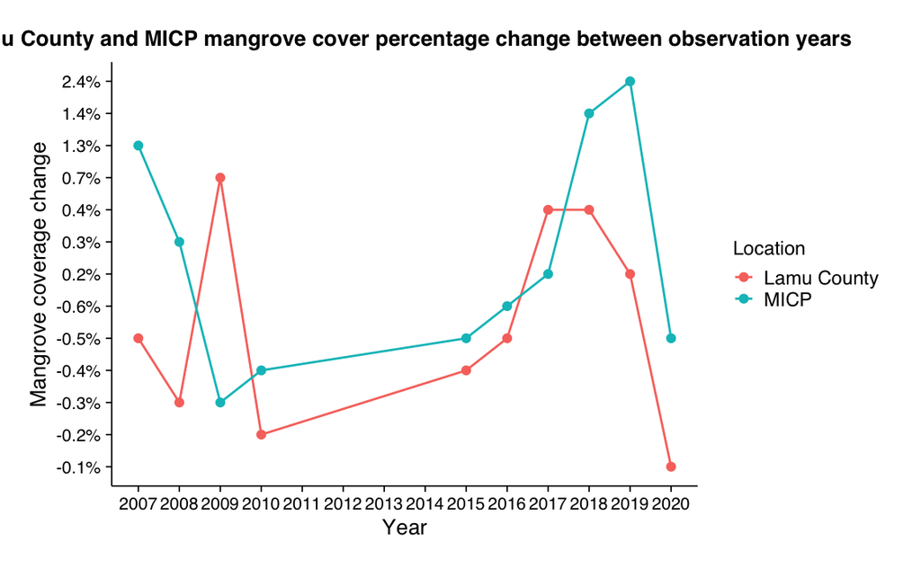

```r
fig1 <- ggplot(data=df9, aes(x=year, y=percentchange, group=location,
                           colour=location)) +
  geom_line() +
  geom_point() +
  theme_fancy() +
  theme(legend.position="right") +
  ggtitle("Lamu County and MICP mangrove cover percentage change between observation years", ) +
  theme(plot.title = element_text(face="bold")) +
  xlab("Year") +
  ylab("Mangrove coverage change") +
  labs(color='Location') +
  scale_x_continuous(breaks = scales::pretty_breaks(n = 11))
fig1
```

Save the graph into the plots folder.

```r
filename = "Lamu County and MICP mangrove cover percentage change between observation years"

ggsave(
  fig1,
  filename = paste0("Plots/", filename, ".png"),
  width = 23,
  height = 17,
  units = "cm"
)

ggsave(
  fig1,
  filename = paste0("Plots/", filename, ".pdf"),
  width = 23,
  height = 17,
  units = "cm"
)
```

## Absolute change visualisation

Create scatter plots and bar charts to visualise the absolute change in mangrove cover in the MICP and Lamu County across the 24 year period of observation. Bar chart Y axis’ are not truncated to provide visual context on the degree of change over time. The line graph Y axis’ are scaled at 3% above the maximum value and 3% below the minimum value for both MICP and Lamu County to minimise line graph distortion. Summaries of each data frame are created to check the max and min values. Scatter plots and bar charts are created in one image and saved into the plots folder.

Y axis scaler set to 3% to minimise graph distortion.

```r
y_axis_scaler <- 0.03
y_axis_scaler
```

```
[1] 0.03
```

Create a summary of the MICP data.

```r
summary(df7)
```

```
     year           Total_Mangroves_Hectares     change
 Length:11          Min.   :163.5            Min.   :-0.0063528
 Class :character   1st Qu.:164.2            1st Qu.:-0.0043134
 Mode  :character   Median :165.9            Median :-0.0002654
                    Mean   :165.9            Mean   : 0.0034883
                    3rd Qu.:166.3            3rd Qu.: 0.0107314
                    Max.   :170.2            Max.   : 0.0240803
                                             NA's   :1
 percentchange        location
 Length:11          Length:11
 Class :character   Class :character
 Mode  :character   Mode  :character
```

Calculate MICP data min and max values and store as a vector.

```r
manda_range <- range(df7$Total_Mangroves_Hectares)
manda_range
```

```
[1] 163.4956 170.1915
```

Define the MICP line graph Y axis upper limit as 3% above the MICP data max value to minimise distortion.

```r
manda_y_axis_max <- manda_range[2] * (1+y_axis_scaler)
manda_y_axis_max
```

```
[1] 175.2972
```

Define the MICP line graph Y axis lower limit as 3% below the MICP data min value to minimise distortion.

```r
manda_y_axis_min <- manda_range[1] * (1-y_axis_scaler)
manda_y_axis_min
```

```
[1] 158.5907
```

Convert MICP year column to numeric.

```r
df7$year = as.numeric(as.character(df7$year))
df7
```

| year | Total_Mangroves_Hectares | change | percentchange | location |
| --- | --- | --- | --- | --- |
| 1996 | 163.7020 | NA | NA | MICP |
| 2007 | 165.8768 | 0.013285116 | 1.3% | MICP |
| 2008 | 166.3861 | 0.003070351 | 0.3% | MICP |
| 2009 | 165.9309 | -0.002735805 | -0.3% | MICP |
| 2010 | 165.3161 | -0.003705157 | -0.4% | MICP |
| 2015 | 164.5409 | -0.004689198 | -0.5% | MICP |
| 2016 | 163.4956 | -0.006352828 | -0.6% | MICP |
| 2017 | 163.8561 | 0.002204952 | 0.2% | MICP |
| 2018 | 166.1896 | 0.014241154 | 1.4% | MICP |
| 2019 | 170.1915 | 0.024080328 | 2.4% | MICP |

[output cut: 1 more lines]

Create a summary of the Lamu County data.

```r
summary(df8)
```

```
     year           Total_Mangroves_Hectares     change
 Length:11          Min.   :34641            Min.   :-0.0047886
 Class :character   1st Qu.:34791            1st Qu.:-0.0035322
 Mode  :character   Median :34902            Median :-0.0018472
                    Mean   :34878            Mean   :-0.0002793
                    3rd Qu.:34958            3rd Qu.: 0.0032025
                    Max.   :35030            Max.   : 0.0071533
                                             NA's   :1
 percentchange        location
 Length:11          Length:11
 Class :character   Class :character
 Mode  :character   Mode  :character
```

Calculate Lamu data min and max values and store as a vector.

```r
lamu_range <- range(df8$Total_Mangroves_Hectares)
lamu_range
```

```
[1] 34640.63 35030.33
```

Define the Lamu line graph Y axis upper limit as 3% above the Lamu data max value to minimise distortion.

```r
lamu_y_axis_max <- lamu_range[2] * (1+y_axis_scaler)
lamu_y_axis_max
```

```
[1] 36081.24
```

Define the Lamu line graph Y axis lower limit as 3% below the Lamu data min value to minimise distortion.

```r
lamu_y_axis_min <- lamu_range[1] * (1-y_axis_scaler)
lamu_y_axis_min
```

```
[1] 33601.41
```

Convert Lamu year column to numeric.

```r
df8$year = as.numeric(as.character(df8$year))
df8
```

| year | Total_Mangroves_Hectares | change | percentchange | location |
| --- | --- | --- | --- | --- |
| 1996 | 35030.33 | NA | NA | Lamu County |
| 2007 | 34869.01 | -0.004605072 | -0.5% | Lamu County |
| 2008 | 34775.34 | -0.002686236 | -0.3% | Lamu County |
| 2009 | 35024.10 | 0.007153275 | 0.7% | Lamu County |
| 2010 | 34940.58 | -0.002384803 | -0.2% | Lamu County |
| 2015 | 34807.31 | -0.003814207 | -0.4% | Lamu County |
| 2016 | 34640.63 | -0.004788575 | -0.5% | Lamu County |
| 2017 | 34764.13 | 0.003565178 | 0.4% | Lamu County |
| 2018 | 34901.89 | 0.003962852 | 0.4% | Lamu County |
| 2019 | 34975.70 | 0.002114541 | 0.2% | Lamu County |

[output cut: 1 more lines]

Create line and bar plots showing mangrove coverage over time in Lamu County and the MICP.

```r
p1 <- ggplot(data=df8, aes(x=year, y=Total_Mangroves_Hectares, group=1)) +
    geom_line() +
    geom_point() +
  theme_fancy() +
  ylim(lamu_y_axis_min, lamu_y_axis_max) +
  ggtitle("Lamu County") +
  xlab("Year") +
  ylab("Mangroves in Ha")

p2 <- ggplot(data=df7, aes(x=year, y=Total_Mangroves_Hectares, group=1)) +
    geom_line() +
    geom_point() +
  theme_fancy() +
  ylim(manda_y_axis_min, manda_y_axis_max) +
  ggtitle("MICP") +
  xlab("Year") +
  ylab("Mangroves in Ha")

p3 <- ggplot(data=df8, aes(x=year, y=Total_Mangroves_Hectares)) +
    geom_bar(stat="identity") +
  theme_fancy() +
  ggtitle("Lamu County") +
  xlab("Year") +
  ylab("Mangroves in Ha")

p4 <- ggplot(data=df7, aes(x=year, y=Total_Mangroves_Hectares)) +
    geom_bar(stat="identity") +
  theme_fancy() +
  ggtitle("MICP") +
  xlab("Year") +
  ylab("Mangroves in Ha")

fig2 <- p1 + p2 + p3 + p4 + plot_annotation(tag_levels = 'a') +
  plot_annotation(title = 'Lamu County and MICP mangrove cover 1996 to 2020', theme = theme(plot.title = element_text(size = 12, face="bold")))
```

[output not shown]

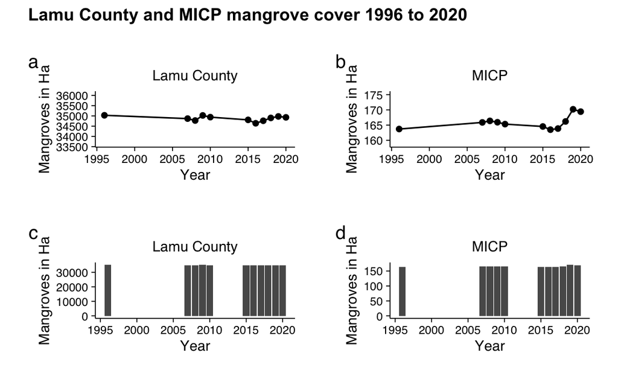

```r
fig2
```

Save the plots to the plots folder.

```r
filename = "Lamu County vs MICP cover change 1996-2020 2"

ggsave(
  fig2,
  filename = paste0("Plots/", filename, ".png"),
  width = 23,
  height = 17,
  units = "cm"
)

ggsave(
  fig2,
  filename = paste0("Plots/", filename, ".pdf"),
  width = 23,
  height = 17,
  units = "cm"
)
```